# 01-Temporal-Coordination

Olena Tykhostup

2024-01-19

This is the code used for data analysis reported in Chapter 5 of the dissertation “Multimodal annotation and analysis of a Narrative problem solving task in English, Idi, and Russian”. It analyzes pointing gestures and their spoken affiliates. It loads and cleans the data, calculates durations, and visualizes patterns. It examines the relationship between gestures and affiliates using linear regression and summarizes data through central tendencies. The script also explores the timing and overlap of gestures and affiliates.

## Load packages

```r
library(here)
library(tidyverse)
library(lubridate)
```

## Load in the data

```r
rawCoartData <- read.csv(here("data","coart_time_eng.csv"), header = F)
```

## Transform and clean the dataset for analysis

Gesture ID 8 was excluded from the analysis due to its significantly longer duration compared to others, indicating a possible idiosyncrasy rather than a representative trend. This exclusion ensures the analysis remains focused on typical pointing gesture durations.

```r
cleanedCoartData <- rawCoartData %>%
  mutate(V1 = gsub('@1', '', V1)) %>% # Remove '@1' from V1 column values
  pivot_wider(names_from = V1, values_from = V8) %>% # Reshape data: two columns for each event type
  mutate(event = if_else(!is.na(Point_form), "gest", "affil")) %>% # Create a new column 'event' to denote event type
  select(1,3,6,9) %>% # Keep only relevant columns
  rename(begin = V2, end = V4, dur = V7) %>%
  arrange(begin) %>%
  mutate_at("event", factor) %>%
  mutate_at(c("begin","end"),
            function(x) as.POSIXct(as.character(x),
                                   format = "%H:%M:%OS")) %>%
  group_by(event) %>% # Group data by event type
  mutate(id = row_number()) %>% # Assign an ID number to each pair of events
  group_by(id) %>% # Group data by the new ID values
  pivot_wider(names_from = event,
              values_from = c(begin, end, dur)) %>% # Reshape data: times of two events per row
  mutate(begin_diff = if_else(begin_gest <= begin_affil,
                              (begin_affil - begin_gest)*(-1),
                              begin_gest - begin_affil)) %>% # Calculate the difference in start times between events
  mutate(end_diff = if_else(end_gest <= end_affil,
                            (end_affil - end_gest)*(-1),
                            end_gest - end_affil)) %>% # Calculate the difference in end times between events
  mutate(dur_affil = dur_affil*0.001, dur_gest = dur_gest*0.001) %>% # Event durations from milliseconds to seconds
  mutate(relative_begin_gest = begin_diff + 2)%>% # Relative start time difference with a fixed reference
  mutate(relative_end_gest = end_diff + 4) %>% # Relative end time difference with a fixed reference
  filter(id!=8) %>% # Remove outlier with ID 8
  mutate(gest_dur_msec = dur_gest*1000) %>%
  mutate(affil_dur_msec = dur_affil*1000)
```

## Instpect the df

```r
str(cleanedCoartData)
```

```
## gropd_df [37 × 13] (S3: grouped_df/tbl_df/tbl/data.frame)
##  $ id                 : int [1:37] 1 2 3 4 5 6 7 9 10 11 ...
##  $ begin_gest         : POSIXct[1:37], format: "2024-04-08 00:00:58" "2024-04-08 00:01:11" ...
##  $ begin_affil        : POSIXct[1:37], format: "2024-04-08 00:00:59" "2024-04-08 00:01:10" ...
##  $ end_gest           : POSIXct[1:37], format: "2024-04-08 00:01:00" "2024-04-08 00:01:12" ...
##  $ end_affil          : POSIXct[1:37], format: "2024-04-08 00:00:59" "2024-04-08 00:01:10" ...
##  $ dur_gest           : num [1:37] 1.906 1.155 0.69 1.325 0.866 ...
##  $ dur_affil          : num [1:37] 0.442 0.181 0.678 0.186 0.744 0.769 0.181 0.291 0.452 0.075 ...
##  $ begin_diff         : 'difftime' num [1:37] -0.84500002861023 0.736999988555908 -0.152000188827515 -0.207000017166138 ...
##   ..- attr(*, "units")= chr "secs"
##  $ end_diff           : 'difftime' num [1:37] 0.61899995803833 1.71099996566772 -0.140000104904175 0.932000160217285 ...
##   ..- attr(*, "units")= chr "secs"
##  $ relative_begin_gest: 'difftime' num [1:37] 1.15499997138977 2.73699998855591 1.84799981117249 1.79299998283386 ...
##   ..- attr(*, "units")= chr "secs"
##  $ relative_end_gest  : 'difftime' num [1:37] 4.61899995803833 5.71099996566772 3.85999989509583 4.93200016021729 ...
##   ..- attr(*, "units")= chr "secs"
##  $ gest_dur_msec      : num [1:37] 1906 1155 690 1325 866 ...
##  $ affil_dur_msec     : num [1:37] 442 181 678 186 744 769 181 291 452 75 ...
##  - attr(*, "groups")= tibble [37 × 2] (S3: tbl_df/tbl/data.frame)
##   ..$ id   : int [1:37] 1 2 3 4 5 6 7 9 10 11 ...
##   ..$ .rows: list<int> [1:37]
##   .. ..$ : int 1
##   .. ..$ : int 2
##   .. ..$ : int 3
##   .. ..$ : int 4
##   .. ..$ : int 5
##   .. ..$ : int 6
##   .. ..$ : int 7
##   .. ..$ : int 8
##   .. ..$ : int 9
##   .. ..$ : int 10
##   .. ..$ : int 11
##   .. ..$ : int 12
##   .. ..$ : int 13
##   .. ..$ : int 14
##   .. ..$ : int 15
##   .. ..$ : int 16
##   .. ..$ : int 17
##   .. ..$ : int 18
##   .. ..$ : int 19
##   .. ..$ : int 20
##   .. ..$ : int 21
##   .. ..$ : int 22
##   .. ..$ : int 23
##   .. ..$ : int 24
##   .. ..$ : int 25
##   .. ..$ : int 26
##   .. ..$ : int 27
##   .. ..$ : int 28
##   .. ..$ : int 29
##   .. ..$ : int 30
##   .. ..$ : int 31
##   .. ..$ : int 32
##   .. ..$ : int 33
##   .. ..$ : int 34
##   .. ..$ : int 35
##   .. ..$ : int 36
##   .. ..$ : int 37
##   .. ..@ ptype: int(0)
##   ..- attr(*, ".drop")= logi TRUE
```

```r
head(cleanedCoartData)
```

```
## # A tibble: 6 × 13
## # Groups:   id [6]
##      id begin_gest          begin_affil         end_gest
##   <int> <dttm>              <dttm>              <dttm>
## 1     1 2024-04-08 00:00:58 2024-04-08 00:00:59 2024-04-08 00:01:00
## 2     2 2024-04-08 00:01:11 2024-04-08 00:01:10 2024-04-08 00:01:12
## 3     3 2024-04-08 00:01:18 2024-04-08 00:01:19 2024-04-08 00:01:19
## 4     4 2024-04-08 00:02:36 2024-04-08 00:02:36 2024-04-08 00:02:38
## 5     5 2024-04-08 00:03:15 2024-04-08 00:03:15 2024-04-08 00:03:16
## 6     6 2024-04-08 00:03:18 2024-04-08 00:03:20 2024-04-08 00:03:20
## # ℹ 9 more variables: end_affil <dttm>, dur_gest <dbl>, dur_affil <dbl>,
## #   begin_diff <drtn>, end_diff <drtn>, relative_begin_gest <drtn>,
## #   relative_end_gest <drtn>, gest_dur_msec <dbl>, affil_dur_msec <dbl>
```

## Create a plot to visualize the durations of pointing gestures and their affiliates

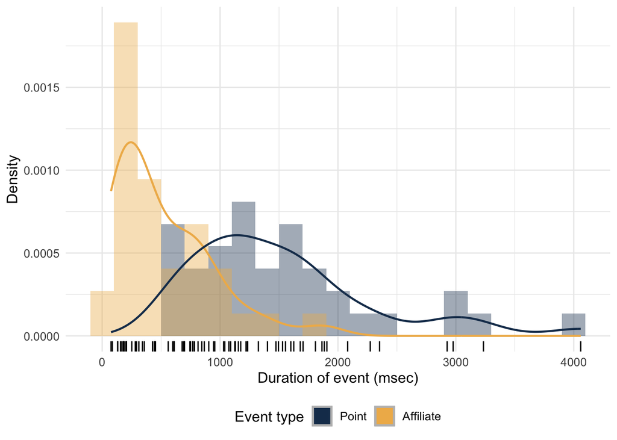

```r
point_affil_dur_hist <- cleanedCoartData %>%
  ggplot() +
  geom_histogram(aes(x=cleanedCoartData$gest_dur_msec, y = after_stat(density),
                     fill = "#183A5A"),
                 alpha = 0.4,
                 binwidth = 200) + # Histogram for gesture duration
  geom_histogram(aes(x=cleanedCoartData$affil_dur_msec, y = after_stat(density),
                     fill = "#EFB758"),
                 alpha = 0.4,
                 binwidth = 200) + # Histogram for affiliate duration
  geom_density(aes(x=cleanedCoartData$affil_dur_msec),
               col = "#EFB758", size=0.8) + # Density plot for affiliate duration
  geom_density(aes(x=cleanedCoartData$gest_dur_msec),
               col = "#183A5A", size=0.8) + # Density plot for gesture duration
  geom_rug(aes(x=cleanedCoartData$gest_dur_msec, y = NULL)) +
  geom_rug(aes(x=cleanedCoartData$affil_dur_msec, y = NULL)) +
  theme_minimal() +
  labs(x = 'Duration of event (msec)',
       y = 'Density') +
  theme(text = element_text(size=12),
        legend.position = "bottom") +
  scale_fill_manual(values=c("#183A5A", "#EFB758"),
                    labels = c("Point", "Affiliate"),
                    aesthetics = c("colour", "fill"),'Event type') +
  guides(fill = guide_legend(override.aes = list(colour = "grey", size = 0.1)))

point_affil_dur_hist
```

Save plot:

```r
# As PNG
png(here("figures", "fppt-eng-hist-point-affil-durations.png"),
    width = 15, height = 10, units = "cm", res = 500)
point_affil_dur_hist
dev.off()
```

```r
# As PDF
pdf(here("figures", "fppt-eng-hist-point-affil-durations.pdf"),
    width = 6, height = 4)
point_affil_dur_hist
dev.off()
```

## Make scatter plot and fit a linear regression model to visualize

## the relationship between gesture and affiliate durations

```r
# Summarize data
summary(cleanedCoartData[6:7])
```

```
##     dur_gest       dur_affil
##  Min.   :0.560   Min.   :0.0750
##  1st Qu.:1.030   1st Qu.:0.1860
##  Median :1.325   Median :0.3570
##  Mean   :1.522   Mean   :0.5114
##  3rd Qu.:1.809   3rd Qu.:0.7490
##  Max.   :4.059   Max.   :1.8640
```

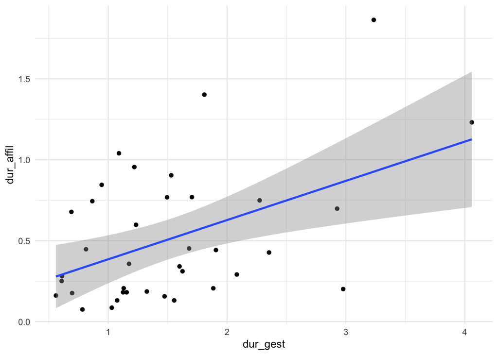

```r
# Scatter plot
ggplot(cleanedCoartData, aes(x = dur_gest, y = dur_affil)) +
  geom_point() +
  stat_smooth(method = lm) +
  theme_minimal()
```

```r
# Fit a linear model
model <- lm(dur_gest ~ dur_affil, data = cleanedCoartData)
summary(model)
```

```
##
## Call:
## lm(formula = dur_gest ~ dur_affil, data = cleanedCoartData)
##
## Residuals:
##     Min      1Q  Median      3Q     Max
## -0.9813 -0.5242 -0.1047  0.3753  1.8907
##
## Coefficients:
##             Estimate Std. Error t value Pr(>|t|)
## (Intercept)   1.0620     0.1881   5.647 2.25e-06 ***
## dur_affil     0.8987     0.2879   3.121   0.0036 **
## ---
## Signif. codes:  0 '***' 0.001 '**' 0.01 '*' 0.05 '.' 0.1 ' ' 1
##
## Residual standard error: 0.7115 on 35 degrees of freedom
## Multiple R-squared:  0.2177, Adjusted R-squared:  0.1954
## F-statistic: 9.742 on 1 and 35 DF,  p-value: 0.0036
```

```r
# Conf intervals of the model coefficients
confint(model)
```

```
##                 2.5 %   97.5 %
## (Intercept) 0.6802154 1.443749
## dur_affil   0.3141529 1.483190
```

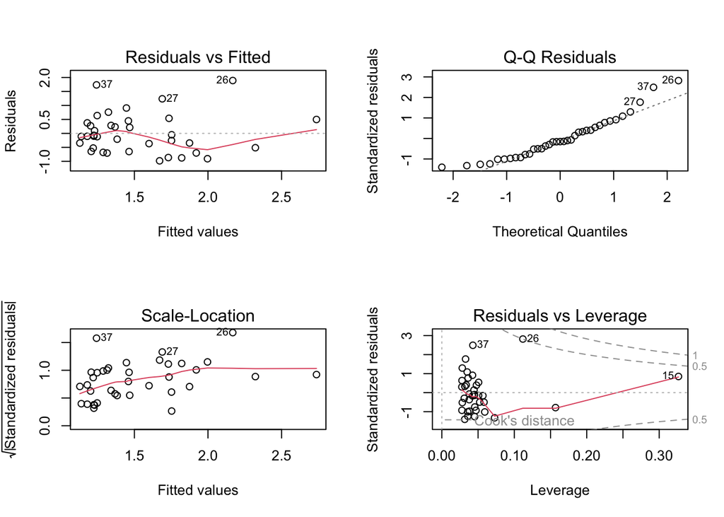

```r
# Diagnostic plots for assessing model assumptions
par(mfrow=c(2,2))
plot(model)
```

```r
par(mfrow=c(1,1))
```

This linear regression model shows that, in line with the hypothesis, there is a statistically significant linear relationship between the duration of gestures and the duration of affiliates. However, the modest R-squared value of 0.2177 indicates that only approximately 21% of the variability in gesture duration can be explained by the duration of affiliates. While this suggests a relationship, it also implies that there are other factors not included in our model that contribute to the variability in gesture duration. The Residuals vs. Fitted plot, although not perfect, does not reveal a clear pattern of increasing or decreasing variance, indicating that homoscedasticity is not severely violated. The Normal Q-Q plot indicates some deviation from normality, particularly in the tails.

## Calculate and compare central tendencies (mean, median, mode) of gesture and affiliate durations

```r
# Function to calculate mode
getmode <- function(v) {
   uniqv <- unique(v)
   uniqv[which.max(tabulate(match(v, uniqv)))]
}

# Create a dataframe for central tendencies
central_tendencies <- data.frame(
    Type = c("Affiliate", "Gesture"),
    Mean = c(mean(cleanedCoartData$affil_dur_msec, na.rm = TRUE),
             mean(cleanedCoartData$gest_dur_msec, na.rm = TRUE)),
    Median = c(median(cleanedCoartData$affil_dur_msec, na.rm = TRUE),
               median(cleanedCoartData$gest_dur_msec, na.rm = TRUE)),
    Mode = c(getmode(cleanedCoartData$affil_dur_msec),
             getmode(cleanedCoartData$gest_dur_msec))
)

# Print the df
print(central_tendencies)
```

```
##        Type      Mean Median Mode
## 1 Affiliate  511.4054    357  181
## 2   Gesture 1521.5676   1325 1906
```

## Code events into those where gestures starte before affiliates or vice versa and compare

```r
# Add a variable to indicate which behavior comes first
gestureAffiliationOrder <- cleanedCoartData %>%
  mutate(event = case_when(begin_gest <= begin_affil ~ "gest_first",
                           TRUE ~ "affil_first")) %>%
  mutate_at("event", factor)

# Contingency table
gestureAffiliationOrder_table <- table(gestureAffiliationOrder$event)

# Chi-square
chisq.test(gestureAffiliationOrder_table)
```

```
##
##  Chi-squared test for given probabilities
##
## data:  gestureAffiliationOrder_table
## X-squared = 11.919, df = 1, p-value = 0.0005557
```

## Calculate central tendencies of the overlaps

```r
# Mean, median, and mode of overlaps by event type
overlap_stats <- gestureAffiliationOrder %>%
  group_by(event) %>%
  summarize(
    Mean = mean(begin_diff, na.rm = TRUE),
    Median = median(begin_diff, na.rm = TRUE),
    Mode = getmode(begin_diff)
  )

# Print the df
print(overlap_stats)
```

```
## # A tibble: 2 × 4
##   event       Mean            Median            Mode
##   <fct>       <drtn>          <drtn>           <dbl>
## 1 gest_first  -0.7278966 secs -0.3559999 secs -0.845
## 2 affil_first  0.3041250 secs  0.2465000 secs  0.737
```

## Visualize realtive co-occurence of gestures and affiliates

This plot shows when pointing gestures occur relative to their spoken affiliates. Each gesture has two points: a start and an end, connected by a line. The x-axis tells us when these gestures take place. The yellow box represents the time of occurence of spoken affilliates. It has two sides: a start and an end. It is scaled, so its length is not meaningful. To understand the plot, see how the gestures match up with the boundaries of the yellow box, revealing how gestures and their spoken affiliates are timed.

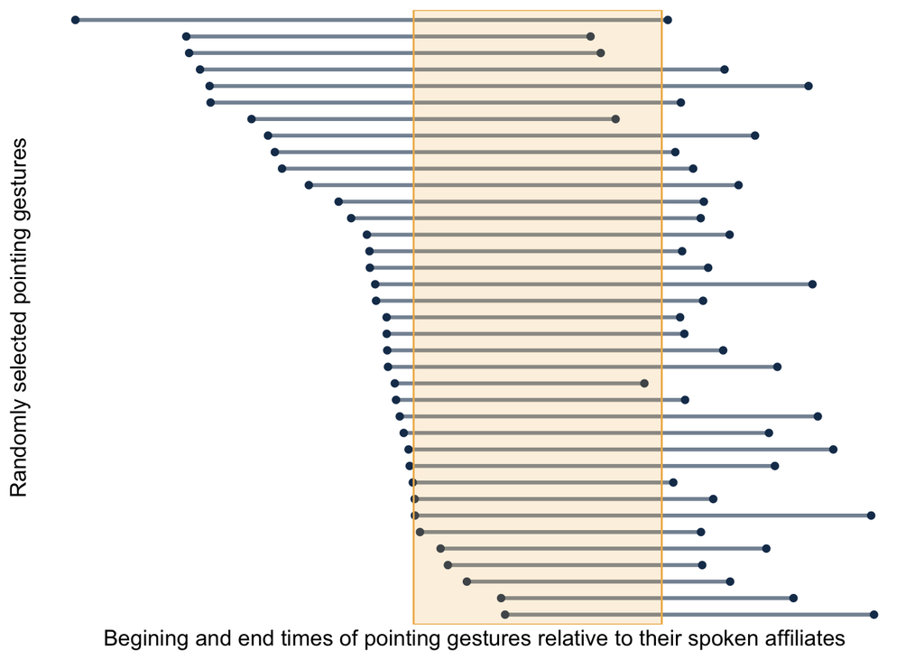

```r
point_aff_overlap_ggpolt <- ggplot(data = cleanedCoartData) +
  geom_point(aes(x = relative_begin_gest,
                 y = reorder(id, -relative_begin_gest)),
             color="#183A5A") +
  geom_point(aes(x = relative_end_gest,
                 y = reorder(id, -relative_begin_gest)),
             color="#183A5A") +
  geom_segment(aes(x = relative_begin_gest, xend = relative_end_gest,
                   y = reorder(id, -relative_begin_gest),
                   yend = reorder(id, -relative_begin_gest)),
               color="#183A5A", size=1, alpha=0.6) +
  annotate("rect", xmin=2, xmax=4, ymin=-Inf, ymax=Inf,
           alpha=0.2, color="#EFB758", fill="#EFB758") +
  theme_minimal() +
  xlim(-1, 7) +
  labs(x = 'Begining and end times of pointing gestures relative to their spoken affiliates',
       y = 'Randomly selected pointing gestures') +
  theme(axis.text = element_blank(),
        text = element_text(size=12)) +
  scale_x_continuous(breaks = NULL) +
  scale_y_discrete(breaks = NULL)
point_aff_overlap_ggpolt
```

## Save plot